# Literate programming in R

Tips & Tricks

@annakrystalli @ Sheffield R Users Group

06/06/2017

# What’s literate programming

## **Code that is human readable!**

> (ie like literature)

## Elements of `.Rmd`

#### `R` code chunks

[figure not shown]

Quick Cheat sheet

## Many output formats supported

n.b. will focus on `html`. Anything refering to .Rmd also works on notebooks

## Not covering!!

- [markdown](https://github.com/adam-p/markdown-here/wiki/Markdown-Cheatsheet) basics
- [rmarkdowng](http://rmarkdown.rstudio.com/) basics

#### some resources

- [rmarkdown tutorial](https://annakrystalli.github.io/UNAM/rmarkdown.nb.html)
- [rmarkdown reference guide](https://www.rstudio.com/wp-content/uploads/2015/03/rmarkdown-reference.pdf)

## **Three different approaches**

### Code and documentation in **`.Rmd`**.

- - Extract code to `.R` using **`purl()`**.

### Code in **`.R`**, annotations in **`.Rmd`**.

- - **`read_chunks("script.R")`** and call in `.Rmd`

### Code + documentation in `.R`.

- - use [`roxygen2`](https://cran.r-project.org/web/packages/roxygen2/vignettes/roxygen2.html) annotation + **`spin("script.R")`** -> **`.html`**

## You can achieve same results through all approaches!

#### But different approaches might work better for different types of docs.

- **Vignettes / READMEs**
- **Reports**
  - progress reports
  - results reports
- **Functions**

### Dependent on the balance of text vs code vs **how you prefer to work**

## `.Rmd` (+ `knitr` -> `html`)

- **Main body** is **`markdown`** (annotations)
- **`R`** in **code chunks**
- I use it for progress reports that do not require reproducibility or results reports to which all variables are supplied as parameters.
- I might also use it for a vignette and extract the workflow described using `knitr::purl()`

### examples

- **Dummy example: example-rmd1.Rmd** .Rmd, html
- **Example in action**

## **rmacroRDM vignette:** .Rmd, html, `purl`ed .R

### Using `knitr::purl` (`Rmd` -> `R`)

If your main code base is in an `.Rmd` or you’d like to extract the code from a vignette you can use `purl()` to *tangle* code out of a literate programming doc.

#### **`purl`** takes many of the same arguments as `knit()` of which most important are:

- **`input`:** path to the input `.Rdm` file
- **`output`:** output file path to write to
- **`documentation`:** an integer specifying the level of documentation to go the tangled script:
  - **0** means pure code (discard all text chunks)
  - **1** (default) means add the chunk headers to code
  - **2** means add all text chunks to code as roxygen comments

#### examples

```r
file <- "example-rmd1"
for(docu in 0:2){
    knitr::purl(input = paste0("Rmd/", file, ".Rmd"),
                output = paste0("R/", file, "_", docu,".R"),
                documentation = docu)
}
```

- [**example-rmd1_0.R**](https://github.com/annakrystalli/lit-prog/blob/master/R/example-rmd1_0.R)
- [**example-rmd1_1.R**](https://github.com/annakrystalli/lit-prog/blob/master/R/example-rmd1_1.R)
- [**example-rmd1_2.R**](https://github.com/annakrystalli/lit-prog/blob/master/R/example-rmd1_2.R)

## Annotation in `.Rmd` + code in `.R`.

#### Store and develop your code in an **`.R`** script

- make sure to **name chunks of code** following the convention:

  ```
  ## ---- code-chunk-name ----
  r.code <- do.summat
  ```

- **read `R` code chunks** into your `.Rmd` document using **`knitr::read_chunks`** (need to load knitr library within the Rmd)
- run chunks by **creating blank `R` chunks** and **naming them** with appropriate chunk names in your `.Rmd`, eg.

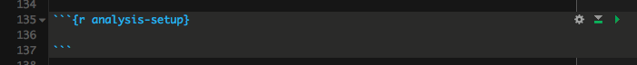

## Render with `rmarkdown::render()`

You can render an `.Rmd` externally by calling `markdown::render`

```r
render(input, output_format = NULL, output_file = NULL, output_dir = NULL,
       output_options = NULL,  params = NULL)
```

e.g. I rendered this presentation as an **.html** [**handout**](https://annakrystalli.github.io/lit-prog/handout/presentation.html) document into the `handout/` directory:

```r
file <- "presentation"
render(input = paste0("Rmd/", file, ".Rmd"),
       html_document(theme = "journal"),
       output_file = paste0("../handout/", file, ".html"))
```

## `.R` + `Roxygen2` + [`knirt::spin`](http://deanattali.com/2015/03/24/knitrs-best-hidden-gem-spin/)

Good for when the code is the focus and only minimal annotation required. Not ideal if you want to write extensively

### **principles**

- **input is an `.R`** script rather than a literate programming document.
- **Start lines with:**
  - **`#'`** to indicate lines to be treated **as `md`** e.g.
    - `#' ### header` will be a ### h3 header
    - `#' some **bold**` text results in some **bold** text.
  - **`#+`** to indicate lines to be treated **as code chunk options**.
- use **`knitr::spin`** instead of `knitr::knit` (the default for .Rmd)

### example

- I edited the `purl` **`.R` code** output **`example-rmd1_2.R`** adding **`#+`** to indicate **code chunk option lines** to create [**`example-3_r2html.R`**](https://github.com/annakrystalli/lit-prog/blob/master/R/example-3_r2html.R)
- I used **`spin()`** to render it to [**`example-3_r2html.html`**](https://annakrystalli.github.io/lit-prog/example-3_r2html.html)

```r
spin("R/example-3_r2html.R")
```

## roxygen2 function documentation

- Use **roxygen2** notation to **document functions.**
- First step to **bulding your** [**own package**](http://kbroman.org/pkg_primer/pages/docs.html).
- Makes it easy to **generate required format** to support **help files**

[Example](https://github.com/kbroman/pkg_primer/blob/gh-pages/example/stage3/R/plot_crayons.R) by Karl Broman

## roxygen2 skeleton for functions

In Rstudio, with the cursor in the body of a function, you can insert a roxygen skeleton using **code > Insert Roxygen Skeleton**

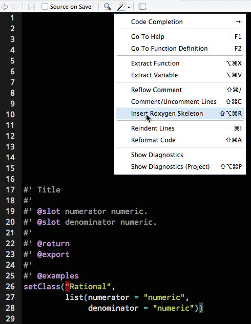

## outro: extra info

## repo with materials: https://github.com/annakrystalli/lit-prog

### Xaringan

New presentation package: [Xaringan](https://github.com/yihui/xaringan)

### yolo:true in YAML -> suprise Karl Broman face!